# cSurvival User Guide

v1.0.0 25/11/2021

# 1 Select project(s)

On top left, click the dropdown widget. You may either a) scroll down, or b) type in keywords, to find your project(s) of interest.

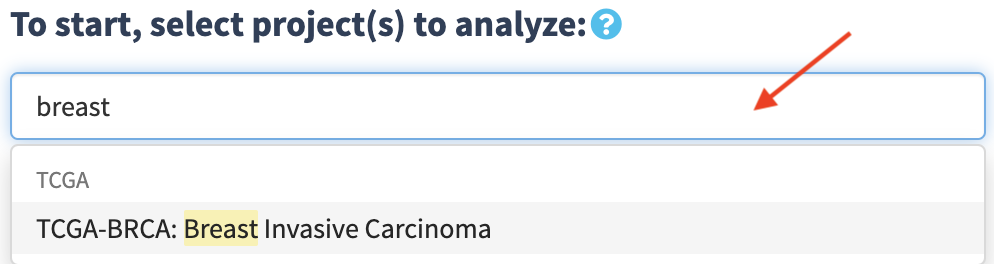

Click and select your project(s) of interest. Then, click **Confirm selection!** to proceed.

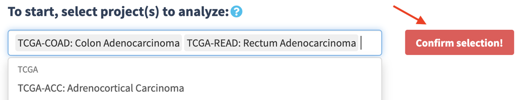

To re-select project(s), click **Reset selection**.

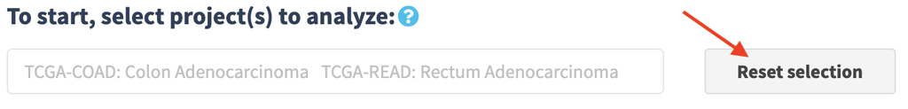

# 2 Censoring

Censoring allows analysis with a specified time interval. You may choose a censoring time in days, months (30.4375 days), or years (365.25 days). For a selected clinical endpoint (e.g. overall survival (OS), progression-free survival (PFS)), if the time-to-event is larger than the defined time, we set censoring status to 0 and time to the defined time; if the time-to-event is smaller than or equal to the defined time, we set censoring status to 1 and time stays unchanged. By default, cases are censored at 10 years.

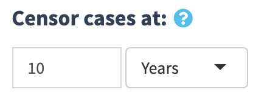

# 3 Single or interaction

Under **No. of analysis:**, enter or click the upper arrow button to **2** to analyze interactions between biomarkers. Choose **1** to analyze a single biomarker.

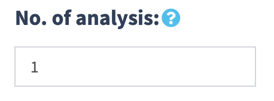

# 4 TCGA: linical endpoint

If TCGA, select the clinical endpoint of interest. Recommendations are provided according to [TCGA pan-cancer clinical study (Liu et al., Cell, 2018)](https://www.ncbi.nlm.nih.gov/pmc/articles/PMC6066282/). You may also click on the lightblue book button for the full published recommendation table.

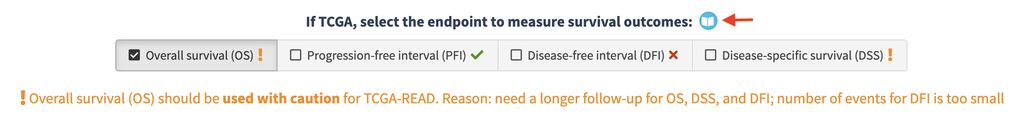

# 5 DepMap: cell lines & gene/drug

Using DepMap data, cSurvival can assess how a biomarker or combinations of biomarkers affect(s) the knockout (CRISPR) / knockdown (RNAi) effect of a gene, or the sensitivity to a drug compound. First, select the type of DepMap data to analyze:

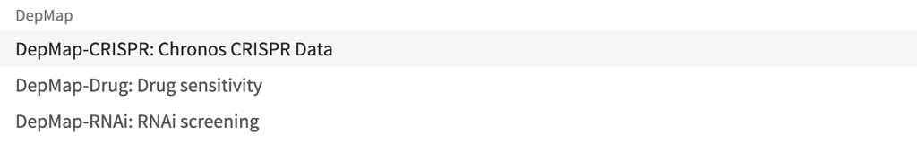

Next, select the cancer type(s) to study. You may type in keywords to search your cancer type(s) of interest.

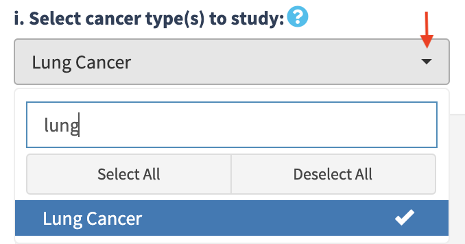

Optionally, filter the cell lines by subtypes. By default, all subtypes of the selected cancer type(s) are selected.

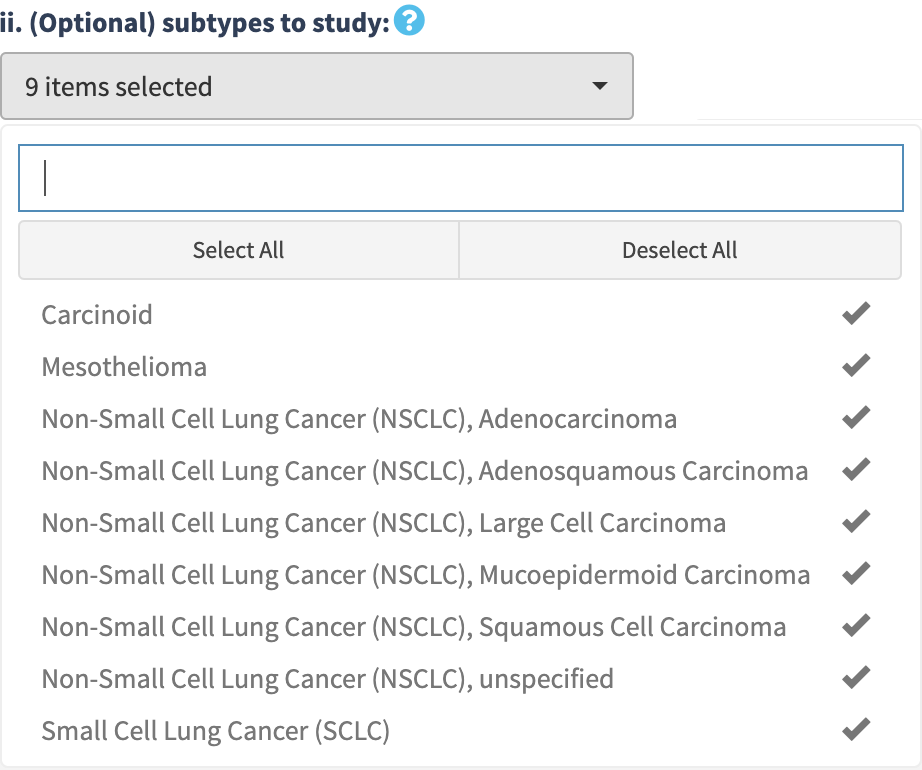

Optionally, manually select specific cell lines. By default, all cell lines of the selected subtype(s) are selected.

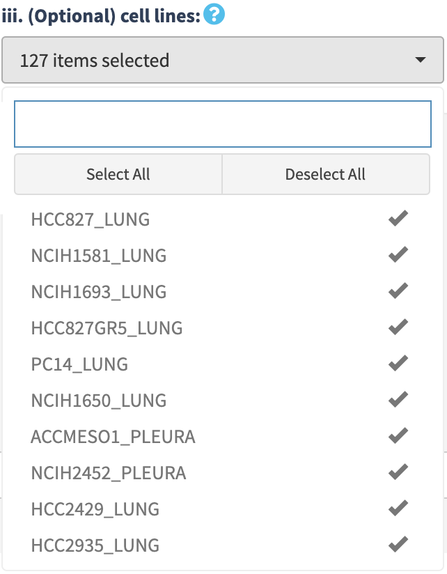

Then, type to search, and select your gene (or drug) of interest.

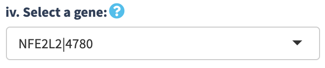

# 6 Select biomarker(s)

cSurvival supports survival analysis with a wide range of biomarkers including gene or GS expression, somatic mutation, microRNA expression, DNA methylation, and protein expression. In addition, two biomarkers can be selected at a time for interaction analysis.

Mandatory fields are marked with an orange asterisk.

## 6.1 Single biomarker

Make sure **No. of analysis** is **1**. You will see a light grey panel in the center. First, select data category of interest.

### 6.1.1 Gene-level biomarker

Select **Gene or locus** to study if the expression level, mutational status, copy number, methylation, or protein level of a gene or locus correlates with poorer/better survival:

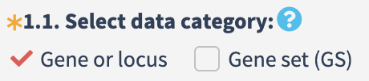

Next, select the type of molecular data to analyze:

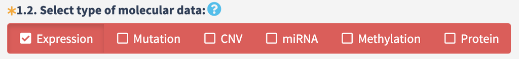

- **Expression**: a gene’s expression level
- **Mutation**: a gene’s mutational status
- **CNV**: copy number variation of a DNA segment
- **miRNA**: a microRNA’s expression
- **Methylation**: methylation level of a DNA segment
- **Protein**: expression level of a protein

Then, type to search your gene of interest:

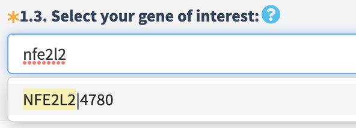

Make sure you have clicked on the gene so it is properly selected:

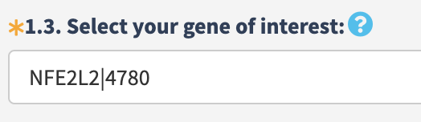

If “Expression”, option is provided to normalize the selected gene’s expression against another gene, or a gene set.

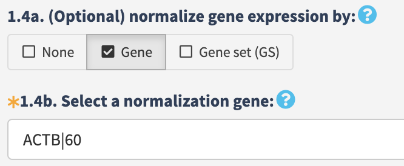

### 6.1.2 GS-level biomarker

Select **Gene set** to study if the average expression level of a gene set correlates with cancer survival, e.g. genes in the same pathway, TF targets, drug targets, miRNA targets, interacting proteins, or user-defined list of genes:

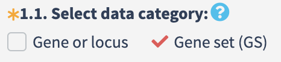

Next, select **Library** (default) to choose a gene set from [eVITTA](https://academic.oup.com/nar/article/49/W1/W207/6279840) to analyze a pathway, a biological process, a cellular location, a transcriptional factor, a drug, or a gene’s interacting partners.

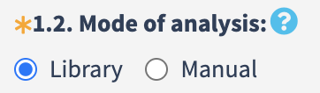

Then, select a database. For full list of available databases, visit [easyGSEA User Guide](https://tau.cmmt.ubc.ca/eVITTA/documentation/index2.html#db):

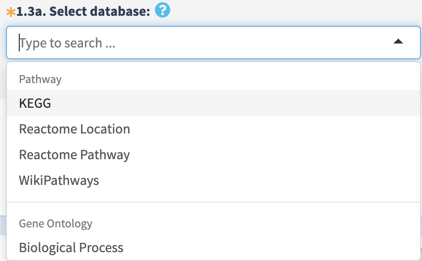

After that, gene sets from the selected database will be loaded. Search for keywords (e.g. glycolysis, chemokine, signaling) and select the one of interest:

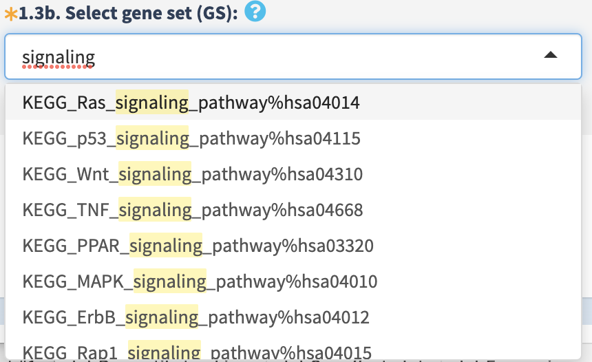

(Optional) You could filter out gene sets that contains your gene(s) of interest, in HUGO symbol format, delimited by “&” (and) or “|” (or). “|” is evaluated before “&”. Example: MYC&TP53|BCL2&BRCA1|BRCA2 is evaluated as MYC&(TP53|BCL2)&(BRCA1|BRCA2), which means MYC and (TP53 or BCL2) and (BRCA1 or BRCA2). A maximum of 10 genes are supported. Click the magnifier button to search and filter; click the cross button to cancel the filter.

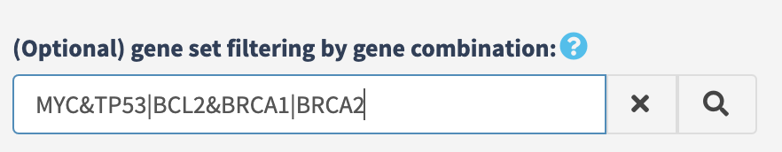

(Optional) After filtering, only gene sets containing the gene(s) will be displayed:

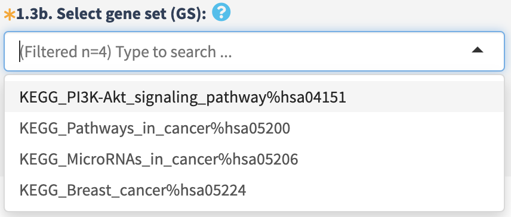

Click to select your gene set of interest. Upon successful selection, feedback is provided showing the genes contained in the gene set. To the right, you could click the red download button to download the gene list, or click the red link button for more details about the selected gene set from its original database.

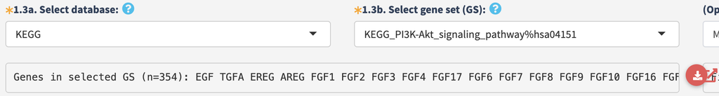

Alternatively, select **Manual** to enter your own list of genes.

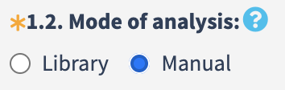

Enter your genes in HUGO symbol format, delimited by newline, space or comma. Click **Submit** to submit your list. Feedback is provided upon successful submission.

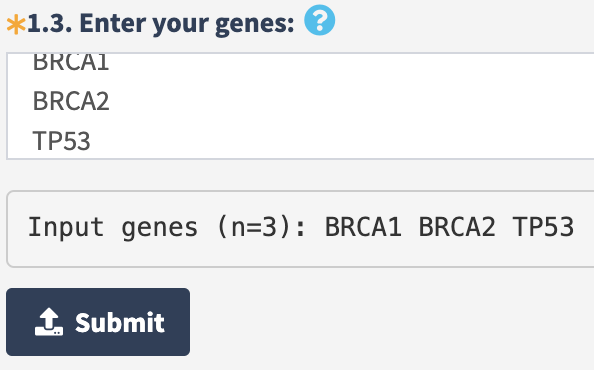

## 6.2 Two biomarkers

Make sure **No. of analysis** is increased to **2**. Then you will see two panels:

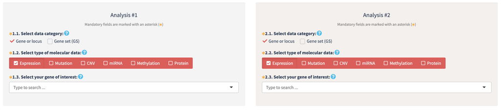

Select each biomarker in each panel. Below are guidelines for different combinations of biomarkers. For more detailed explanation for individual biomarker selection, see above **6.1 Single biomarker**.

### 6.2.1 Gene and gene

Select **Gene or locus** in both panels:

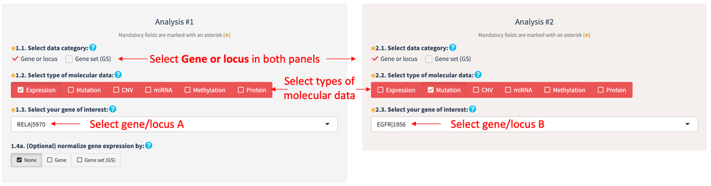

### 6.2.2 GS and GS

### 6.2.3 Gene and GS

# 7 Run parameters

# 8 Continuous variables

# 9 Categorical variables

# 10 Joint analysis

# 11 Use cases

## 11.1 Single biomarker analysis

### 11.1.1 Expression

### 11.1.2 Mutation

### 11.1.3 microRNA Expression

### 11.1.4 DNA methylation

### 11.1.5 Protein expression

### 11.1.6 GS expression

## 11.2 Biomarker interaction analysis

### 11.2.1 Expression & expression

### 11.2.2 Mutation & expression

### 11.2.3 Mutation & GS expression

### 11.2.4 GS expression & GS expression

## 11.3 DepMap

### 11.3.1 CRISPR/RNAi

### 11.3.2 Drug sensitivity

# 12 Support

**Feel free to reach us at jcheng@cmmt.ubc.ca or taubert@cmmt.ubc.ca if you have any questions!**

Q&A - known issues

Q: I can’t click on any button or select any options. Seems the website is not responding. Why is that?  
A: Two possible reasons. First, check whether your internet is stable. Second, We might experience high traffic. Please come back after a few minutes. If problem still exists. Please email us.